# Lending_Club_Default_Analysis

### Annual Income Bucket (annual_inc_b)

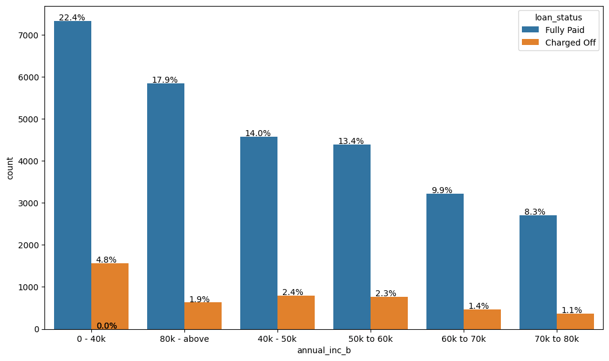

```python
# Overall ratio of Charge Offs against the total
series_plot(loan, 'annual_inc_b', 'loan_status')
```

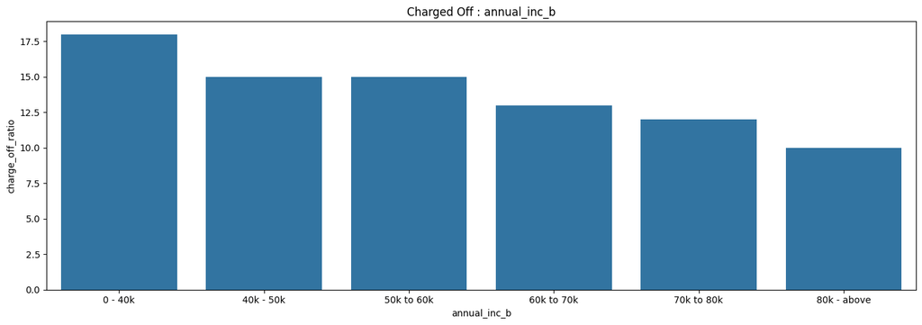

| loan_status | annual_inc_b | Charged Off | Fully Paid | total | charge_off_ratio |
| --- | --- | --- | --- | --- | --- |
| 0 | 0 - 40k | 1569 | 7324 | 8893 | 18.0 |
| 1 | 40k - 50k | 793 | 4576 | 5369 | 15.0 |
| 2 | 50k to 60k | 763 | 4386 | 5149 | 15.0 |
| 3 | 60k to 70k | 469 | 3222 | 3691 | 13.0 |
| 4 | 70k to 80k | 372 | 2702 | 3074 | 12.0 |
| 5 | 80k - above | 629 | 5850 | 6479 | 10.0 |

```python
# The ratio of Charge Offs within the category total
ratio_wise_plot(loan, 'annual_inc_b')
```

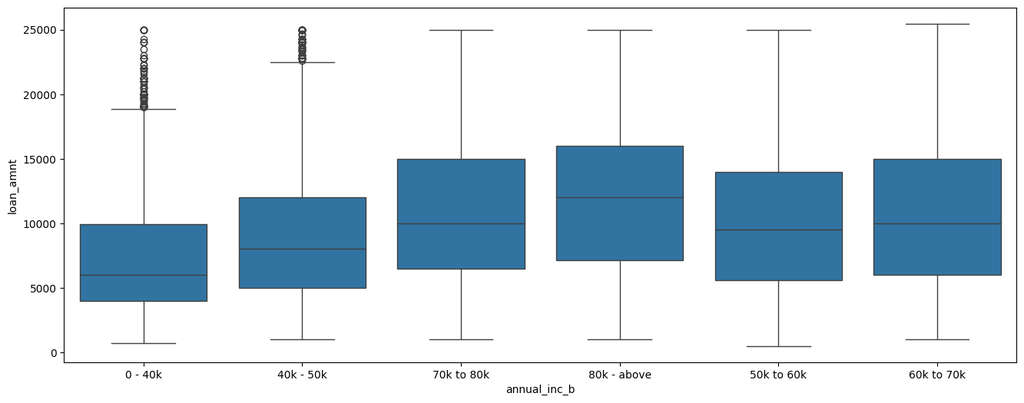

```python
plot.figure(figsize=(16, 6))
sea.boxplot(y=loan.loan_amnt, x=loan.annual_inc_b)
plot.show()
```

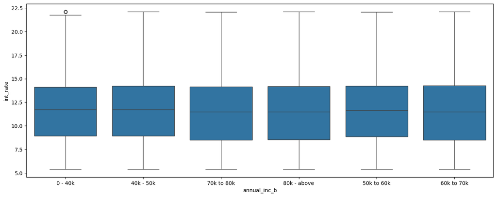

```python
plot.figure(figsize=(16, 6))
sea.boxplot(y=loan.int_rate, x=loan.annual_inc_b)
plot.show()
```

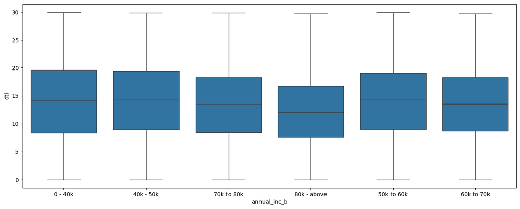

```python
plot.figure(figsize=(16, 6))
sea.boxplot(y=loan.dti, x=loan.annual_inc_b)
plot.show()
```

- Annual income range of 0-40K has the highest charge offs
- Charge off ratio within the bucket of 0-40K have highest Charge Offs
- **Inferences**
  - Income range of 0-40K have the highest risk
  - Income range 80000+ has less chances of charged off.
  - Increase in annual income charged off proportion decreases.

### Loan Amount Bucket (loan_amnt_b)

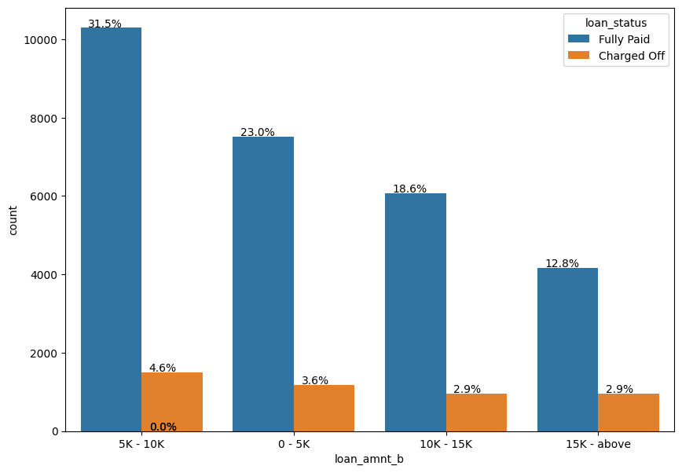

```python
# Overall ratio of Charge Offs against the total
series_plot(loan, 'loan_amnt_b', 'loan_status')
```

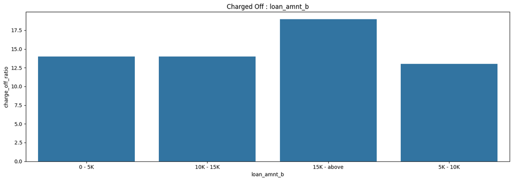

| loan_status | loan_amnt_b | Charged Off | Fully Paid | total | charge_off_ratio |
| --- | --- | --- | --- | --- | --- |
| 0 | 0 - 5K | 1180 | 7520 | 8700 | 14.0 |
| 1 | 10K - 15K | 954 | 6077 | 7031 | 14.0 |
| 2 | 15K - above | 958 | 4170 | 5128 | 19.0 |
| 3 | 5K - 10K | 1503 | 10293 | 11796 | 13.0 |

```python
# The ratio of Charge Offs within the category total
ratio_wise_plot(loan, 'loan_amnt_b')
```

- Based on volume highest percentage of Charge Offs are in the category of 5K to 10k of loan_ammount
- The Charge Off ratio of all the customer;s within the loan_amount of 15K and above is at the highest CHarge Off risk
- **Inferences**
  - Charge Off risk of loan amount 15K and above is at the highest risk

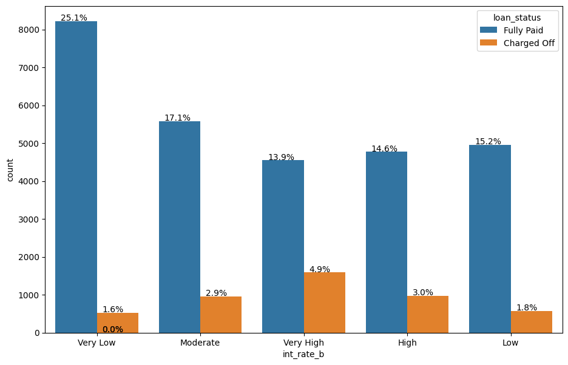

```python
# Overall ratio of Charge Offs against the total
series_plot(loan, 'int_rate_b', 'loan_status')
```

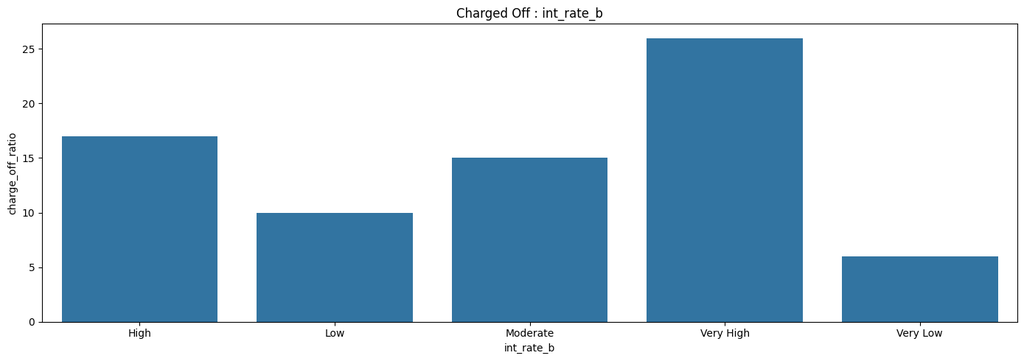

| loan_status | int_rate_b | Charged Off | Fully Paid | total | charge_off_ratio |
| --- | --- | --- | --- | --- | --- |
| 0 | High | 966 | 4769 | 5735 | 17.0 |
| 1 | Low | 576 | 4957 | 5533 | 10.0 |
| 2 | Moderate | 948 | 5575 | 6523 | 15.0 |
| 3 | Very High | 1587 | 4547 | 6134 | 26.0 |
| 4 | Very Low | 518 | 8212 | 8730 | 6.0 |

```python
# The ratio of Charge Offs within the category total
ratio_wise_plot(loan, 'int_rate_b')
```

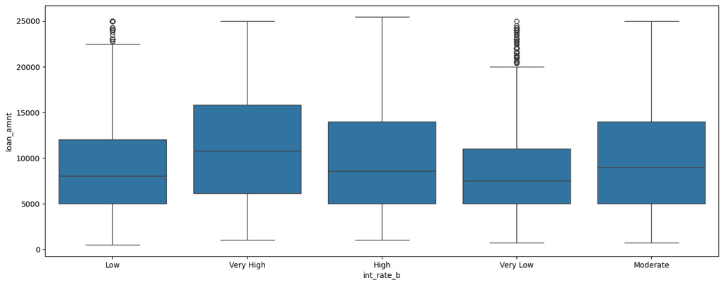

```python
plot.figure(figsize=(16, 6))
sea.boxplot(y=loan.loan_amnt, x=loan.int_rate_b)
plot.show()
```

- Based on volume and based on Charge Off ratio within the category, the Very High interest rates are in risk of Charge Off
- Very High interest rate is 15% and above

### Correlation Analysis

```python
corr_loan = loan
```

```python
# Printing column info to analyse missing values, empty values in a column
print(corr_loan.info())
```

```
<class 'pandas.core.frame.DataFrame'>
Index: 32655 entries, 0 to 39680
Data columns (total 26 columns):
 #   Column                Non-Null Count  Dtype
---  ------                --------------  -----
 0   id                    32655 non-null  int64
 1   loan_amnt             32655 non-null  float64
 2   term                  32655 non-null  int64
 3   int_rate              32655 non-null  float64
 4   installment           32655 non-null  float64
 5   grade                 32655 non-null  object
 6   emp_length            32655 non-null  float64
 7   home_ownership        32655 non-null  object
 8   annual_inc            32655 non-null  float64
 9   verification_status   32655 non-null  object
```

[output cut: 19 more lines]

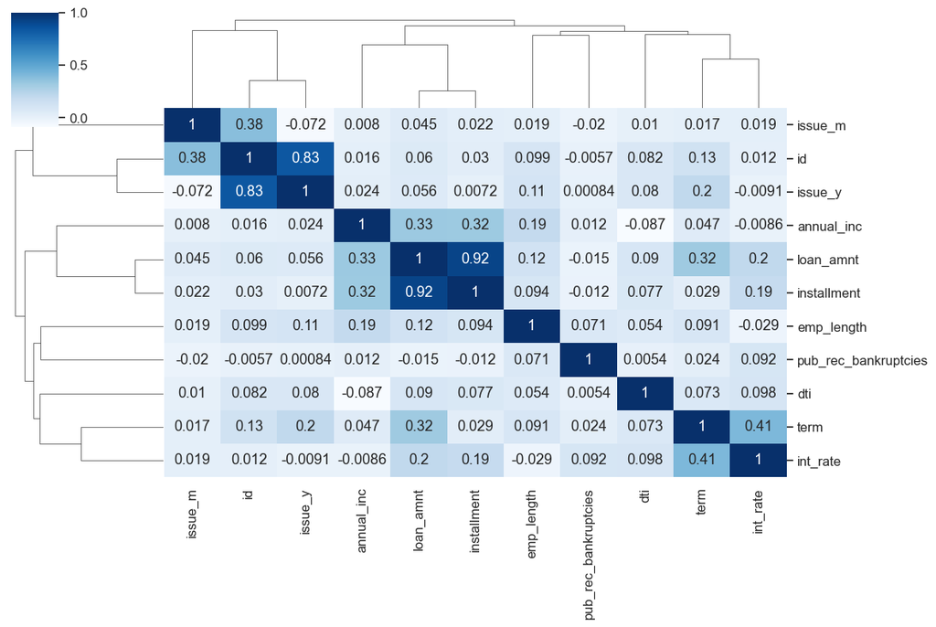

```python
# corr_loan.to_csv('snapshot.corr_loan.csv')
numeric_columns = corr_loan.select_dtypes(
    include=['int32', 'int64', 'float64']).columns
# Create a new dataframe with only the numeric columns
corr = corr_loan[numeric_columns].drop_duplicates().corr()

# plot.figure(figsize=(15, 8))
# sea.heatmap(corr, annot=True, cmap='Blues')
# plot.show()

sea.set(font_scale=1.1)
sea.clustermap(corr, annot=True, figsize=(12, 8), cmap="Blues")
plot.show()
```

```python
# Data-Cleanning
# Dropping redundant fields related to the 'loan_amnt'. They show high correlation in the corr-matrix
# Dropping fields id which do not contribute to analysis
# Dropping fields issue_y and issue_m
drop_columns = ['installment', 'id', 'issue_y', 'issue_m']
corr_loan = corr_loan.drop(columns=drop_columns)
```

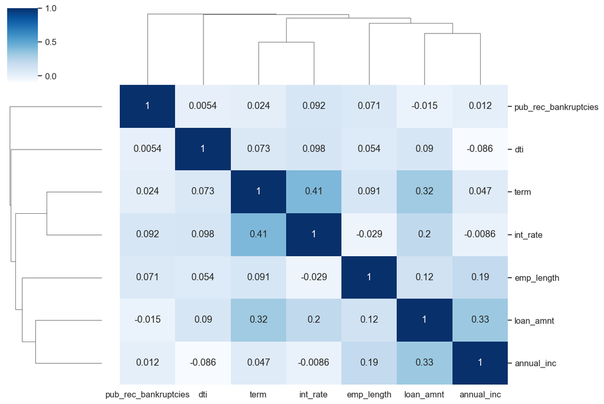

```python
# corr_loan.to_csv('snapshot.corr_loan.csv')
numeric_columns = corr_loan.select_dtypes(
    include=['int32', 'int64', 'float64']).columns
# Create a new dataframe with only the numeric columns
corr = corr_loan[numeric_columns].drop_duplicates().corr()

# plot.figure(figsize=(15, 8))
# sea.heatmap(corr, annot=True, cmap='Blues')
# plot.show()

sea.set(font_scale=1.1)
sea.clustermap(corr, annot=True, figsize=(12, 8), cmap="Blues")
plot.show()
```

**Negative Correlation**

- loan_amnt has negative correlation with pub_rec_bankrupticies
- annual income has a negative correlation with dti

**Strong Correlation**

**Weak Correlation**

- pub_rec_bankruptcies has weak correlation with most of the firlds

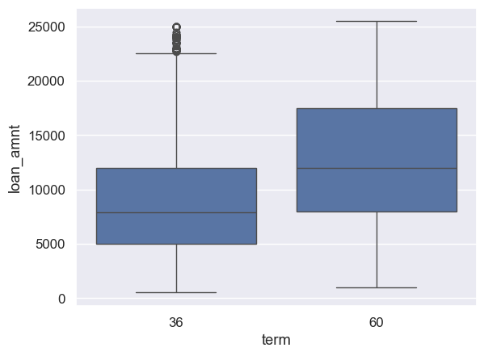

```python
sea.boxplot(x='term', y='loan_amnt', data=corr_loan)
```

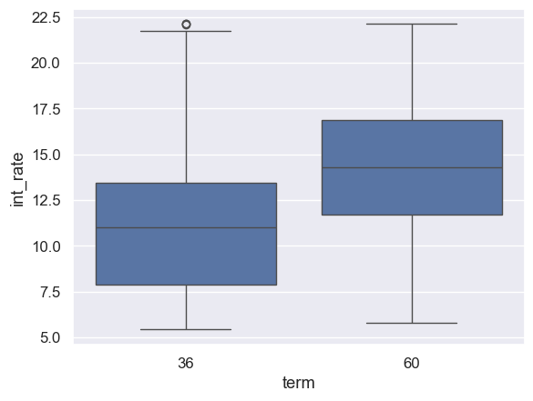

```python
sea.boxplot(x='term', y='int_rate', data=corr_loan)
```

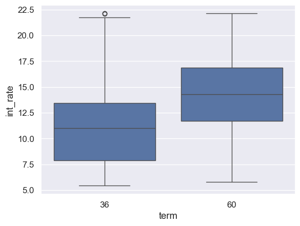

```python
sea.boxplot(x='term', y='int_rate', data=corr_loan)
```

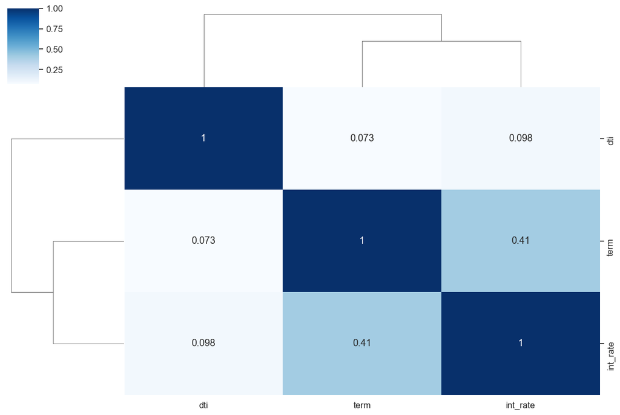

```python
corr = corr_loan.loc[:, ['term', 'int_rate', 'dti']].corr()
sea.set(font_scale=1.1)
sea.clustermap(corr, annot=True, figsize=(12, 8), cmap="Blues")
plot.show()
```

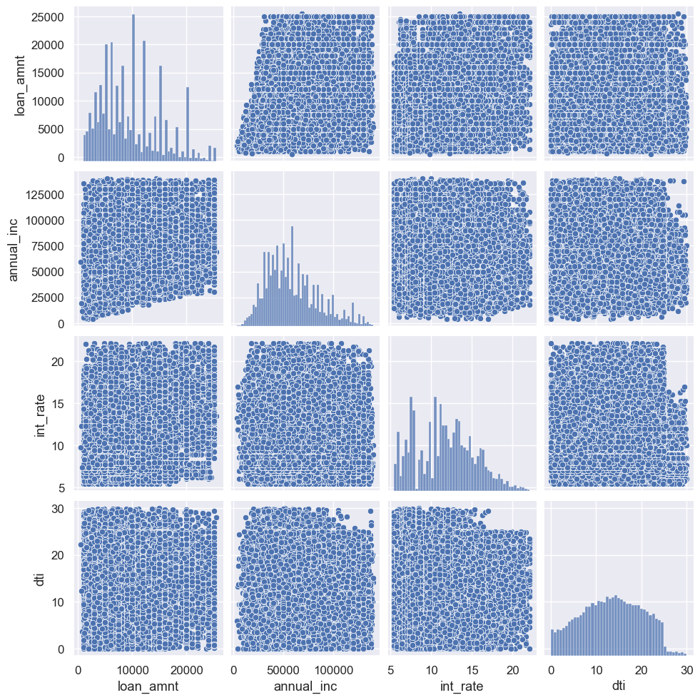

```python
plot.figure(figsize=(6, 10))
sea.pairplot(loan[['loan_amnt', 'annual_inc', 'int_rate', 'dti']])
plot.show()
```